# Risk Factor Analysis

## Outcome Variable

**Outcome Variable:** ever_stunted

## Predictor Variables

**Intervention Variable:** impsan

**Adjustment Set:**

- arm
- sex
- W_mage
- meducyrs
- feducyrs
- hhwealth_quart
- hfoodsec
- W_mhtcm
- W_nrooms
- W_nchldlt5
- W_parity
- impfloor
- safeh20
- delta_W_mage
- delta_meducyrs
- delta_feducyrs
- delta_hhwealth_quart
- delta_hfoodsec
- delta_W_mhtcm
- delta_W_nrooms
- delta_W_nchldlt5
- delta_W_parity
- delta_impfloor
- delta_safeh20

## Stratifying Variables

The analysis was stratified on these variable(s):

- agecat
- studyid
- country

## Data Summary

| agecat | studyid | country | impsan | ever_stunted | n_cell | n |
| --- | --- | --- | --- | --- | --- | --- |
| 0-6 months | ki0047075b-MAL-ED | BANGLADESH | 0 | 0 | 33 | 242 |
| 0-6 months | ki0047075b-MAL-ED | BANGLADESH | 0 | 1 | 5 | 242 |
| 0-6 months | ki0047075b-MAL-ED | BANGLADESH | 1 | 0 | 170 | 242 |
| 0-6 months | ki0047075b-MAL-ED | BANGLADESH | 1 | 1 | 34 | 242 |
| 0-6 months | ki0047075b-MAL-ED | BRAZIL | 0 | 0 | 4 | 210 |
| 0-6 months | ki0047075b-MAL-ED | BRAZIL | 0 | 1 | 0 | 210 |
| 0-6 months | ki0047075b-MAL-ED | BRAZIL | 1 | 0 | 185 | 210 |
| 0-6 months | ki0047075b-MAL-ED | BRAZIL | 1 | 1 | 21 | 210 |
| 0-6 months | ki0047075b-MAL-ED | INDIA | 0 | 0 | 107 | 233 |
| 0-6 months | ki0047075b-MAL-ED | INDIA | 0 | 1 | 18 | 233 |
| 0-6 months | ki0047075b-MAL-ED | INDIA | 1 | 0 | 88 | 233 |
| 0-6 months | ki0047075b-MAL-ED | INDIA | 1 | 1 | 20 | 233 |
| 0-6 months | ki0047075b-MAL-ED | NEPAL | 0 | 0 | 1 | 236 |
| 0-6 months | ki0047075b-MAL-ED | NEPAL | 0 | 1 | 0 | 236 |
| 0-6 months | ki0047075b-MAL-ED | NEPAL | 1 | 0 | 208 | 236 |
| 0-6 months | ki0047075b-MAL-ED | NEPAL | 1 | 1 | 27 | 236 |
| 0-6 months | ki0047075b-MAL-ED | PERU | 0 | 0 | 174 | 263 |
| 0-6 months | ki0047075b-MAL-ED | PERU | 0 | 1 | 24 | 263 |
| 0-6 months | ki0047075b-MAL-ED | PERU | 1 | 0 | 57 | 263 |
| 0-6 months | ki0047075b-MAL-ED | PERU | 1 | 1 | 8 | 263 |
| 0-6 months | ki0047075b-MAL-ED | SOUTH AFRICA | 0 | 0 | 223 | 250 |
| 0-6 months | ki0047075b-MAL-ED | SOUTH AFRICA | 0 | 1 | 23 | 250 |
| 0-6 months | ki0047075b-MAL-ED | SOUTH AFRICA | 1 | 0 | 4 | 250 |
| 0-6 months | ki0047075b-MAL-ED | SOUTH AFRICA | 1 | 1 | 0 | 250 |
| 0-6 months | ki0047075b-MAL-ED | TANZANIA, UNITED REPUBLIC OF | 0 | 0 | 202 | 241 |
| 0-6 months | ki0047075b-MAL-ED | TANZANIA, UNITED REPUBLIC OF | 0 | 1 | 39 | 241 |
| 0-6 months | ki1017093-NIH-Birth | BANGLADESH | 0 | 0 | 327 | 629 |
| 0-6 months | ki1017093-NIH-Birth | BANGLADESH | 0 | 1 | 60 | 629 |
| 0-6 months | ki1017093-NIH-Birth | BANGLADESH | 1 | 0 | 203 | 629 |
| 0-6 months | ki1017093-NIH-Birth | BANGLADESH | 1 | 1 | 39 | 629 |

[output cut: 164 more lines]

The following strata were considered:

- agecat: 0-24 months, studyid: ki0047075b-MAL-ED, country: BANGLADESH
- agecat: 0-24 months, studyid: ki0047075b-MAL-ED, country: BRAZIL
- agecat: 0-24 months, studyid: ki0047075b-MAL-ED, country: INDIA
- agecat: 0-24 months, studyid: ki0047075b-MAL-ED, country: NEPAL
- agecat: 0-24 months, studyid: ki0047075b-MAL-ED, country: PERU
- agecat: 0-24 months, studyid: ki0047075b-MAL-ED, country: SOUTH AFRICA
- agecat: 0-24 months, studyid: ki0047075b-MAL-ED, country: TANZANIA, UNITED REPUBLIC OF
- agecat: 0-24 months, studyid: ki1017093-NIH-Birth, country: BANGLADESH
- agecat: 0-24 months, studyid: ki1017093b-PROVIDE, country: BANGLADESH
- agecat: 0-24 months, studyid: ki1017093c-NIH-Crypto, country: BANGLADESH
- agecat: 0-24 months, studyid: ki1114097-CONTENT, country: PERU
- agecat: 0-24 months, studyid: ki1135781-COHORTS, country: GUATEMALA
- agecat: 0-24 months, studyid: ki1135781-COHORTS, country: INDIA
- agecat: 0-24 months, studyid: ki1135781-COHORTS, country: PHILIPPINES
- agecat: 0-24 months, studyid: ki1148112-LCNI-5, country: MALAWI
- agecat: 0-24 months, studyid: kiGH5241-JiVitA-3, country: BANGLADESH
- agecat: 0-24 months, studyid: kiGH5241-JiVitA-4, country: BANGLADESH
- agecat: 0-6 months, studyid: ki0047075b-MAL-ED, country: BANGLADESH
- agecat: 0-6 months, studyid: ki0047075b-MAL-ED, country: BRAZIL
- agecat: 0-6 months, studyid: ki0047075b-MAL-ED, country: INDIA
- agecat: 0-6 months, studyid: ki0047075b-MAL-ED, country: NEPAL
- agecat: 0-6 months, studyid: ki0047075b-MAL-ED, country: PERU
- agecat: 0-6 months, studyid: ki0047075b-MAL-ED, country: SOUTH AFRICA
- agecat: 0-6 months, studyid: ki0047075b-MAL-ED, country: TANZANIA, UNITED REPUBLIC OF
- agecat: 0-6 months, studyid: ki1017093-NIH-Birth, country: BANGLADESH
- agecat: 0-6 months, studyid: ki1017093b-PROVIDE, country: BANGLADESH
- agecat: 0-6 months, studyid: ki1017093c-NIH-Crypto, country: BANGLADESH
- agecat: 0-6 months, studyid: ki1114097-CONTENT, country: PERU
- agecat: 0-6 months, studyid: ki1135781-COHORTS, country: GUATEMALA
- agecat: 0-6 months, studyid: ki1135781-COHORTS, country: INDIA
- agecat: 0-6 months, studyid: ki1135781-COHORTS, country: PHILIPPINES
- agecat: 0-6 months, studyid: ki1148112-LCNI-5, country: MALAWI
- agecat: 0-6 months, studyid: kiGH5241-JiVitA-3, country: BANGLADESH
- agecat: 0-6 months, studyid: kiGH5241-JiVitA-4, country: BANGLADESH
- agecat: 6-24 months, studyid: ki0047075b-MAL-ED, country: BANGLADESH
- agecat: 6-24 months, studyid: ki0047075b-MAL-ED, country: BRAZIL
- agecat: 6-24 months, studyid: ki0047075b-MAL-ED, country: INDIA
- agecat: 6-24 months, studyid: ki0047075b-MAL-ED, country: NEPAL
- agecat: 6-24 months, studyid: ki0047075b-MAL-ED, country: PERU
- agecat: 6-24 months, studyid: ki0047075b-MAL-ED, country: SOUTH AFRICA
- agecat: 6-24 months, studyid: ki0047075b-MAL-ED, country: TANZANIA, UNITED REPUBLIC OF
- agecat: 6-24 months, studyid: ki1017093-NIH-Birth, country: BANGLADESH
- agecat: 6-24 months, studyid: ki1017093b-PROVIDE, country: BANGLADESH
- agecat: 6-24 months, studyid: ki1017093c-NIH-Crypto, country: BANGLADESH
- agecat: 6-24 months, studyid: ki1114097-CONTENT, country: PERU
- agecat: 6-24 months, studyid: ki1135781-COHORTS, country: GUATEMALA
- agecat: 6-24 months, studyid: ki1135781-COHORTS, country: INDIA
- agecat: 6-24 months, studyid: ki1135781-COHORTS, country: PHILIPPINES
- agecat: 6-24 months, studyid: ki1148112-LCNI-5, country: MALAWI
- agecat: 6-24 months, studyid: kiGH5241-JiVitA-3, country: BANGLADESH
- agecat: 6-24 months, studyid: kiGH5241-JiVitA-4, country: BANGLADESH

## Methods Detail

We’re interested in the causal parameters $E[Y_a]$ for all values of $a \in \mathcal{A}$. These parameters represent the mean outcome if, possibly contrary to fact, we intervened to set all units to have $A=a$. Under the randomization and positivity assumptions, these are identified by the statistical parameters $\psi_a=E_W[E_{Y|A,W}(Y|A=a,W)]$. In addition, we’re interested in the mean of $Y$, $E[Y]$ under no intervention (the observed mean). We will estimate these parameters by using SuperLearner to fit the relevant likelihood factors – $E_{Y|A,W}(Y|A=a,W)$ and $p(A=a|W)$, and then updating our likelihood fit using a joint TMLE.

For unadjusted analyses ($W=\{\}$), initial likelihoods were estimated using Lrnr_glm to estimate the simple $E(Y|A)$ and Lrnr_mean to estimate $p(A)$. For adjusted analyses, a small library containing Lrnr_glmnet, Lrnr_xgboost, and Lrnr_mean was used.

Having estimated these parameters, we will then use the delta method to estimate relative risks and attributable risks relative to a prespecified baseline level of $A$.

[output not shown]

# Results Detail

## Results Plots

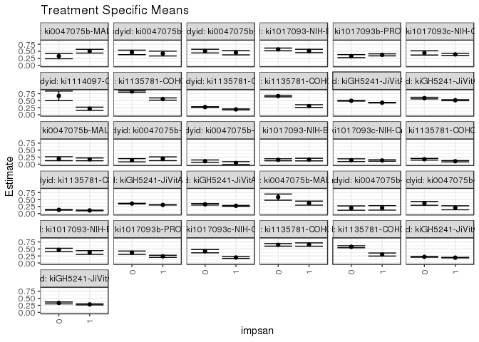

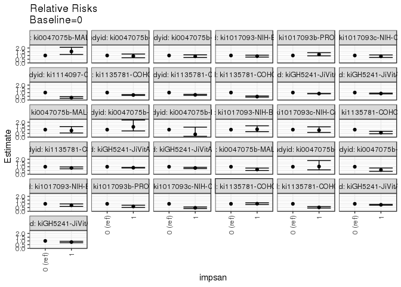

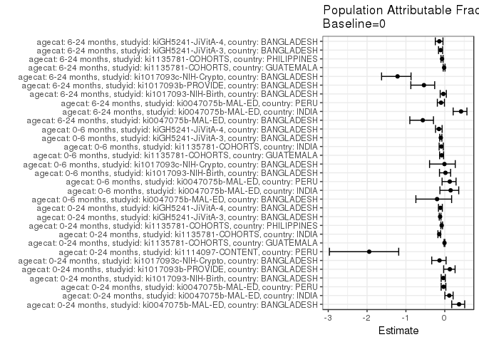

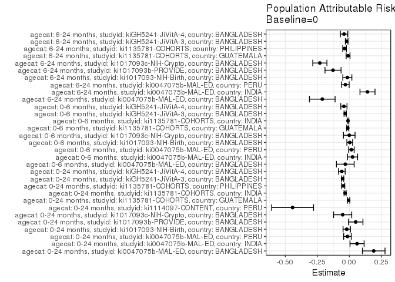

## Results Table

### Parameter: TSM

| agecat | studyid | country | intervention_level | baseline_level | estimate | ci_lower | ci_upper |
| --- | --- | --- | --- | --- | --- | --- | --- |
| 0-24 months | ki0047075b-MAL-ED | BANGLADESH | 0 | NA | 0.3265084 | 0.2325132 | 0.4205036 |
| 0-24 months | ki0047075b-MAL-ED | BANGLADESH | 1 | NA | 0.5020754 | 0.4353310 | 0.5688197 |
| 0-24 months | ki0047075b-MAL-ED | INDIA | 0 | NA | 0.4594435 | 0.3787758 | 0.5401113 |
| 0-24 months | ki0047075b-MAL-ED | INDIA | 1 | NA | 0.4186149 | 0.3322199 | 0.5050098 |
| 0-24 months | ki0047075b-MAL-ED | PERU | 0 | NA | 0.5054949 | 0.4401097 | 0.5708800 |
| 0-24 months | ki0047075b-MAL-ED | PERU | 1 | NA | 0.4492718 | 0.3712577 | 0.5272858 |
| 0-24 months | ki1017093-NIH-Birth | BANGLADESH | 0 | NA | 0.5660217 | 0.5180915 | 0.6139519 |
| 0-24 months | ki1017093-NIH-Birth | BANGLADESH | 1 | NA | 0.5110120 | 0.4508670 | 0.5711569 |
| 0-24 months | ki1017093b-PROVIDE | BANGLADESH | 0 | NA | 0.3262235 | 0.2725064 | 0.3799407 |
| 0-24 months | ki1017093b-PROVIDE | BANGLADESH | 1 | NA | 0.3725117 | 0.3360211 | 0.4090023 |
| 0-24 months | ki1017093c-NIH-Crypto | BANGLADESH | 0 | NA | 0.4407339 | 0.3650202 | 0.5164477 |
| 0-24 months | ki1017093c-NIH-Crypto | BANGLADESH | 1 | NA | 0.3892246 | 0.3522807 | 0.4261686 |
| 0-24 months | ki1114097-CONTENT | PERU | 0 | NA | 0.6712195 | 0.5005030 | 0.8419361 |
| 0-24 months | ki1114097-CONTENT | PERU | 1 | NA | 0.2134804 | 0.1569386 | 0.2700221 |
| 0-24 months | ki1135781-COHORTS | GUATEMALA | 0 | NA | 0.8290401 | 0.8036176 | 0.8544625 |
| 0-24 months | ki1135781-COHORTS | GUATEMALA | 1 | NA | 0.5585641 | 0.5190735 | 0.5980547 |
| 0-24 months | ki1135781-COHORTS | INDIA | 0 | NA | 0.2707798 | 0.2563997 | 0.2851599 |
| 0-24 months | ki1135781-COHORTS | INDIA | 1 | NA | 0.1883146 | 0.1718649 | 0.2047644 |
| 0-24 months | ki1135781-COHORTS | PHILIPPINES | 0 | NA | 0.6648961 | 0.6364256 | 0.6933665 |
| 0-24 months | ki1135781-COHORTS | PHILIPPINES | 1 | NA | 0.3072881 | 0.2584148 | 0.3561613 |
| 0-24 months | kiGH5241-JiVitA-3 | BANGLADESH | 0 | NA | 0.4971294 | 0.4857456 | 0.5085133 |
| 0-24 months | kiGH5241-JiVitA-3 | BANGLADESH | 1 | NA | 0.4282187 | 0.4198266 | 0.4366109 |
| 0-24 months | kiGH5241-JiVitA-4 | BANGLADESH | 0 | NA | 0.5914701 | 0.5619829 | 0.6209574 |
| 0-24 months | kiGH5241-JiVitA-4 | BANGLADESH | 1 | NA | 0.5164350 | 0.4983741 | 0.5344959 |
| 0-6 months | ki0047075b-MAL-ED | BANGLADESH | 0 | NA | 0.1930729 | 0.1226997 | 0.2634461 |
| 0-6 months | ki0047075b-MAL-ED | BANGLADESH | 1 | NA | 0.1705496 | 0.1202417 | 0.2208574 |
| 0-6 months | ki0047075b-MAL-ED | INDIA | 0 | NA | 0.1384195 | 0.0808101 | 0.1960288 |
| 0-6 months | ki0047075b-MAL-ED | INDIA | 1 | NA | 0.1907991 | 0.1237202 | 0.2578779 |
| 0-6 months | ki0047075b-MAL-ED | PERU | 0 | NA | 0.1059634 | 0.0628303 | 0.1490964 |
| 0-6 months | ki0047075b-MAL-ED | PERU | 1 | NA | 0.0393323 | -0.0085467 | 0.0872114 |
| 0-6 months | ki1017093-NIH-Birth | BANGLADESH | 0 | NA | 0.1545861 | 0.1185395 | 0.1906327 |
| 0-6 months | ki1017093-NIH-Birth | BANGLADESH | 1 | NA | 0.1619157 | 0.1158026 | 0.2080288 |
| 0-6 months | ki1017093c-NIH-Crypto | BANGLADESH | 0 | NA | 0.1403248 | 0.0910599 | 0.1895898 |
| 0-6 months | ki1017093c-NIH-Crypto | BANGLADESH | 1 | NA | 0.1300681 | 0.1046274 | 0.1555089 |
| 0-6 months | ki1135781-COHORTS | GUATEMALA | 0 | NA | 0.1733236 | 0.1438990 | 0.2027482 |
| 0-6 months | ki1135781-COHORTS | GUATEMALA | 1 | NA | 0.1029452 | 0.0801203 | 0.1257702 |
| 0-6 months | ki1135781-COHORTS | INDIA | 0 | NA | 0.1324186 | 0.1212128 | 0.1436244 |
| 0-6 months | ki1135781-COHORTS | INDIA | 1 | NA | 0.1106569 | 0.0970007 | 0.1243132 |
| 0-6 months | kiGH5241-JiVitA-3 | BANGLADESH | 0 | NA | 0.3547910 | 0.3437802 | 0.3658018 |
| 0-6 months | kiGH5241-JiVitA-3 | BANGLADESH | 1 | NA | 0.3089531 | 0.3011895 | 0.3167166 |
| 0-6 months | kiGH5241-JiVitA-4 | BANGLADESH | 0 | NA | 0.3294024 | 0.3014866 | 0.3573183 |
| 0-6 months | kiGH5241-JiVitA-4 | BANGLADESH | 1 | NA | 0.2747453 | 0.2595772 | 0.2899134 |
| 6-24 months | ki0047075b-MAL-ED | BANGLADESH | 0 | NA | 0.5860607 | 0.4752583 | 0.6968630 |
| 6-24 months | ki0047075b-MAL-ED | BANGLADESH | 1 | NA | 0.3708446 | 0.2987457 | 0.4429434 |
| 6-24 months | ki0047075b-MAL-ED | INDIA | 0 | NA | 0.1954797 | 0.1175943 | 0.2733652 |
| 6-24 months | ki0047075b-MAL-ED | INDIA | 1 | NA | 0.2019445 | 0.1223222 | 0.2815668 |
| 6-24 months | ki0047075b-MAL-ED | PERU | 0 | NA | 0.3619296 | 0.2937181 | 0.4301412 |
| 6-24 months | ki0047075b-MAL-ED | PERU | 1 | NA | 0.2052382 | 0.1339529 | 0.2765236 |
| 6-24 months | ki1017093-NIH-Birth | BANGLADESH | 0 | NA | 0.4660655 | 0.4076682 | 0.5244628 |
| 6-24 months | ki1017093-NIH-Birth | BANGLADESH | 1 | NA | 0.3727987 | 0.3062848 | 0.4393126 |
| 6-24 months | ki1017093b-PROVIDE | BANGLADESH | 0 | NA | 0.3661218 | 0.3064312 | 0.4258123 |
| 6-24 months | ki1017093b-PROVIDE | BANGLADESH | 1 | NA | 0.2367445 | 0.1986515 | 0.2748375 |
| 6-24 months | ki1017093c-NIH-Crypto | BANGLADESH | 0 | NA | 0.4205741 | 0.3615091 | 0.4796390 |
| 6-24 months | ki1017093c-NIH-Crypto | BANGLADESH | 1 | NA | 0.1955951 | 0.1628068 | 0.2283835 |
| 6-24 months | ki1135781-COHORTS | GUATEMALA | 0 | NA | 0.6461660 | 0.5997822 | 0.6925498 |
| 6-24 months | ki1135781-COHORTS | GUATEMALA | 1 | NA | 0.6566188 | 0.5971112 | 0.7161264 |
| 6-24 months | ki1135781-COHORTS | PHILIPPINES | 0 | NA | 0.5773201 | 0.5422674 | 0.6123728 |
| 6-24 months | ki1135781-COHORTS | PHILIPPINES | 1 | NA | 0.3011551 | 0.2469802 | 0.3553300 |
| 6-24 months | kiGH5241-JiVitA-3 | BANGLADESH | 0 | NA | 0.2180883 | 0.2048205 | 0.2313561 |
| 6-24 months | kiGH5241-JiVitA-3 | BANGLADESH | 1 | NA | 0.1899010 | 0.1811840 | 0.1986180 |
| 6-24 months | kiGH5241-JiVitA-4 | BANGLADESH | 0 | NA | 0.3369269 | 0.3036684 | 0.3701855 |
| 6-24 months | kiGH5241-JiVitA-4 | BANGLADESH | 1 | NA | 0.2846555 | 0.2666855 | 0.3026255 |

### Parameter: E(Y)

| agecat | studyid | country | intervention_level | baseline_level | estimate | ci_lower | ci_upper |
| --- | --- | --- | --- | --- | --- | --- | --- |
| 0-24 months | ki0047075b-MAL-ED | BANGLADESH | NA | NA | 0.5165289 | 0.4534372 | 0.5796206 |
| 0-24 months | ki0047075b-MAL-ED | INDIA | NA | NA | 0.5193133 | 0.4550224 | 0.5836043 |
| 0-24 months | ki0047075b-MAL-ED | PERU | NA | NA | 0.4904943 | 0.4299617 | 0.5510268 |
| 0-24 months | ki1017093-NIH-Birth | BANGLADESH | NA | NA | 0.5453100 | 0.5063654 | 0.5842547 |
| 0-24 months | ki1017093b-PROVIDE | BANGLADESH | NA | NA | 0.3753582 | 0.3394105 | 0.4113058 |
| 0-24 months | ki1017093c-NIH-Crypto | BANGLADESH | NA | NA | 0.3882195 | 0.3532480 | 0.4231911 |
| 0-24 months | ki1114097-CONTENT | PERU | NA | NA | 0.2279070 | 0.1717046 | 0.2841094 |
| 0-24 months | ki1135781-COHORTS | GUATEMALA | NA | NA | 0.8232611 | 0.7980013 | 0.8485210 |
| 0-24 months | ki1135781-COHORTS | INDIA | NA | NA | 0.2372724 | 0.2259059 | 0.2486388 |
| 0-24 months | ki1135781-COHORTS | PHILIPPINES | NA | NA | 0.6164154 | 0.5888226 | 0.6440082 |
| 0-24 months | kiGH5241-JiVitA-3 | BANGLADESH | NA | NA | 0.4439299 | 0.4364087 | 0.4514510 |
| 0-24 months | kiGH5241-JiVitA-4 | BANGLADESH | NA | NA | 0.5322521 | 0.5160648 | 0.5484394 |
| 0-6 months | ki0047075b-MAL-ED | BANGLADESH | NA | NA | 0.1611570 | 0.1147371 | 0.2075770 |
| 0-6 months | ki0047075b-MAL-ED | INDIA | NA | NA | 0.1630901 | 0.1155503 | 0.2106299 |
| 0-6 months | ki0047075b-MAL-ED | PERU | NA | NA | 0.1216730 | 0.0820887 | 0.1612573 |
| 0-6 months | ki1017093-NIH-Birth | BANGLADESH | NA | NA | 0.1573927 | 0.1289105 | 0.1858749 |
| 0-6 months | ki1017093c-NIH-Crypto | BANGLADESH | NA | NA | 0.1392236 | 0.1143819 | 0.1640652 |
| 0-6 months | ki1135781-COHORTS | GUATEMALA | NA | NA | 0.1604755 | 0.1327241 | 0.1882269 |
| 0-6 months | ki1135781-COHORTS | INDIA | NA | NA | 0.1215151 | 0.1126348 | 0.1303954 |
| 0-6 months | kiGH5241-JiVitA-3 | BANGLADESH | NA | NA | 0.3220220 | 0.3152589 | 0.3287851 |
| 0-6 months | kiGH5241-JiVitA-4 | BANGLADESH | NA | NA | 0.2864960 | 0.2726657 | 0.3003263 |
| 6-24 months | ki0047075b-MAL-ED | BANGLADESH | NA | NA | 0.3743590 | 0.3062579 | 0.4424600 |
| 6-24 months | ki0047075b-MAL-ED | INDIA | NA | NA | 0.3367876 | 0.2699375 | 0.4036376 |
| 6-24 months | ki0047075b-MAL-ED | PERU | NA | NA | 0.3303571 | 0.2686253 | 0.3920890 |
| 6-24 months | ki1017093-NIH-Birth | BANGLADESH | NA | NA | 0.4500000 | 0.4023647 | 0.4976353 |
| 6-24 months | ki1017093b-PROVIDE | BANGLADESH | NA | NA | 0.2383838 | 0.2008095 | 0.2759582 |
| 6-24 months | ki1017093c-NIH-Crypto | BANGLADESH | NA | NA | 0.1898527 | 0.1587303 | 0.2209751 |
| 6-24 months | ki1135781-COHORTS | GUATEMALA | NA | NA | 0.6359447 | 0.5906239 | 0.6812655 |
| 6-24 months | ki1135781-COHORTS | PHILIPPINES | NA | NA | 0.5396096 | 0.5064896 | 0.5727297 |
| 6-24 months | kiGH5241-JiVitA-3 | BANGLADESH | NA | NA | 0.1970666 | 0.1890031 | 0.2051301 |
| 6-24 months | kiGH5241-JiVitA-4 | BANGLADESH | NA | NA | 0.2954018 | 0.2790421 | 0.3117615 |

### Parameter: RR

| agecat | studyid | country | intervention_level | baseline_level | estimate | ci_lower | ci_upper |
| --- | --- | --- | --- | --- | --- | --- | --- |
| 0-24 months | ki0047075b-MAL-ED | BANGLADESH | 0 | 0 | 1.0000000 | 1.0000000 | 1.0000000 |
| 0-24 months | ki0047075b-MAL-ED | BANGLADESH | 1 | 0 | 1.5377103 | 1.1285492 | 2.0952148 |
| 0-24 months | ki0047075b-MAL-ED | INDIA | 0 | 0 | 1.0000000 | 1.0000000 | 1.0000000 |
| 0-24 months | ki0047075b-MAL-ED | INDIA | 1 | 0 | 0.9111345 | 0.6970430 | 1.1909825 |
| 0-24 months | ki0047075b-MAL-ED | PERU | 0 | 0 | 1.0000000 | 1.0000000 | 1.0000000 |
| 0-24 months | ki0047075b-MAL-ED | PERU | 1 | 0 | 0.8887761 | 0.7251502 | 1.0893233 |
| 0-24 months | ki1017093-NIH-Birth | BANGLADESH | 0 | 0 | 1.0000000 | 1.0000000 | 1.0000000 |
| 0-24 months | ki1017093-NIH-Birth | BANGLADESH | 1 | 0 | 0.9028133 | 0.7843538 | 1.0391636 |
| 0-24 months | ki1017093b-PROVIDE | BANGLADESH | 0 | 0 | 1.0000000 | 1.0000000 | 1.0000000 |
| 0-24 months | ki1017093b-PROVIDE | BANGLADESH | 1 | 0 | 1.1418909 | 0.9471609 | 1.3766562 |
| 0-24 months | ki1017093c-NIH-Crypto | BANGLADESH | 0 | 0 | 1.0000000 | 1.0000000 | 1.0000000 |
| 0-24 months | ki1017093c-NIH-Crypto | BANGLADESH | 1 | 0 | 0.8831283 | 0.7280327 | 1.0712646 |
| 0-24 months | ki1114097-CONTENT | PERU | 0 | 0 | 1.0000000 | 1.0000000 | 1.0000000 |
| 0-24 months | ki1114097-CONTENT | PERU | 1 | 0 | 0.3180485 | 0.2223765 | 0.4548811 |
| 0-24 months | ki1135781-COHORTS | GUATEMALA | 0 | 0 | 1.0000000 | 1.0000000 | 1.0000000 |
| 0-24 months | ki1135781-COHORTS | GUATEMALA | 1 | 0 | 0.6737480 | 0.6253640 | 0.7258754 |
| 0-24 months | ki1135781-COHORTS | INDIA | 0 | 0 | 1.0000000 | 1.0000000 | 1.0000000 |
| 0-24 months | ki1135781-COHORTS | INDIA | 1 | 0 | 0.6954531 | 0.6283938 | 0.7696687 |
| 0-24 months | ki1135781-COHORTS | PHILIPPINES | 0 | 0 | 1.0000000 | 1.0000000 | 1.0000000 |
| 0-24 months | ki1135781-COHORTS | PHILIPPINES | 1 | 0 | 0.4621596 | 0.3924531 | 0.5442471 |
| 0-24 months | kiGH5241-JiVitA-3 | BANGLADESH | 0 | 0 | 1.0000000 | 1.0000000 | 1.0000000 |
| 0-24 months | kiGH5241-JiVitA-3 | BANGLADESH | 1 | 0 | 0.8613827 | 0.8379141 | 0.8855086 |
| 0-24 months | kiGH5241-JiVitA-4 | BANGLADESH | 0 | 0 | 1.0000000 | 1.0000000 | 1.0000000 |
| 0-24 months | kiGH5241-JiVitA-4 | BANGLADESH | 1 | 0 | 0.8731379 | 0.8227457 | 0.9266166 |
| 0-6 months | ki0047075b-MAL-ED | BANGLADESH | 0 | 0 | 1.0000000 | 1.0000000 | 1.0000000 |
| 0-6 months | ki0047075b-MAL-ED | BANGLADESH | 1 | 0 | 0.8833430 | 0.5525413 | 1.4121930 |
| 0-6 months | ki0047075b-MAL-ED | INDIA | 0 | 0 | 1.0000000 | 1.0000000 | 1.0000000 |
| 0-6 months | ki0047075b-MAL-ED | INDIA | 1 | 0 | 1.3784118 | 0.8290616 | 2.2917710 |
| 0-6 months | ki0047075b-MAL-ED | PERU | 0 | 0 | 1.0000000 | 1.0000000 | 1.0000000 |
| 0-6 months | ki0047075b-MAL-ED | PERU | 1 | 0 | 0.3711882 | 0.1029761 | 1.3379871 |
| 0-6 months | ki1017093-NIH-Birth | BANGLADESH | 0 | 0 | 1.0000000 | 1.0000000 | 1.0000000 |
| 0-6 months | ki1017093-NIH-Birth | BANGLADESH | 1 | 0 | 1.0474144 | 0.7256205 | 1.5119155 |
| 0-6 months | ki1017093c-NIH-Crypto | BANGLADESH | 0 | 0 | 1.0000000 | 1.0000000 | 1.0000000 |
| 0-6 months | ki1017093c-NIH-Crypto | BANGLADESH | 1 | 0 | 0.9269073 | 0.6229828 | 1.3791026 |
| 0-6 months | ki1135781-COHORTS | GUATEMALA | 0 | 0 | 1.0000000 | 1.0000000 | 1.0000000 |
| 0-6 months | ki1135781-COHORTS | GUATEMALA | 1 | 0 | 0.5939481 | 0.4531514 | 0.7784912 |
| 0-6 months | ki1135781-COHORTS | INDIA | 0 | 0 | 1.0000000 | 1.0000000 | 1.0000000 |
| 0-6 months | ki1135781-COHORTS | INDIA | 1 | 0 | 0.8356600 | 0.7197437 | 0.9702449 |
| 0-6 months | kiGH5241-JiVitA-3 | BANGLADESH | 0 | 0 | 1.0000000 | 1.0000000 | 1.0000000 |
| 0-6 months | kiGH5241-JiVitA-3 | BANGLADESH | 1 | 0 | 0.8708029 | 0.8391021 | 0.9037014 |
| 0-6 months | kiGH5241-JiVitA-4 | BANGLADESH | 0 | 0 | 1.0000000 | 1.0000000 | 1.0000000 |
| 0-6 months | kiGH5241-JiVitA-4 | BANGLADESH | 1 | 0 | 0.8340718 | 0.7549825 | 0.9214461 |
| 6-24 months | ki0047075b-MAL-ED | BANGLADESH | 0 | 0 | 1.0000000 | 1.0000000 | 1.0000000 |
| 6-24 months | ki0047075b-MAL-ED | BANGLADESH | 1 | 0 | 0.6327750 | 0.4882522 | 0.8200767 |
| 6-24 months | ki0047075b-MAL-ED | INDIA | 0 | 0 | 1.0000000 | 1.0000000 | 1.0000000 |
| 6-24 months | ki0047075b-MAL-ED | INDIA | 1 | 0 | 1.0330713 | 0.5828209 | 1.8311564 |
| 6-24 months | ki0047075b-MAL-ED | PERU | 0 | 0 | 1.0000000 | 1.0000000 | 1.0000000 |
| 6-24 months | ki0047075b-MAL-ED | PERU | 1 | 0 | 0.5670667 | 0.3868377 | 0.8312649 |
| 6-24 months | ki1017093-NIH-Birth | BANGLADESH | 0 | 0 | 1.0000000 | 1.0000000 | 1.0000000 |
| 6-24 months | ki1017093-NIH-Birth | BANGLADESH | 1 | 0 | 0.7998849 | 0.6462601 | 0.9900282 |
| 6-24 months | ki1017093b-PROVIDE | BANGLADESH | 0 | 0 | 1.0000000 | 1.0000000 | 1.0000000 |
| 6-24 months | ki1017093b-PROVIDE | BANGLADESH | 1 | 0 | 0.6466278 | 0.5160386 | 0.8102639 |
| 6-24 months | ki1017093c-NIH-Crypto | BANGLADESH | 0 | 0 | 1.0000000 | 1.0000000 | 1.0000000 |
| 6-24 months | ki1017093c-NIH-Crypto | BANGLADESH | 1 | 0 | 0.4650670 | 0.3764091 | 0.5746072 |
| 6-24 months | ki1135781-COHORTS | GUATEMALA | 0 | 0 | 1.0000000 | 1.0000000 | 1.0000000 |
| 6-24 months | ki1135781-COHORTS | GUATEMALA | 1 | 0 | 1.0161767 | 0.9092561 | 1.1356701 |
| 6-24 months | ki1135781-COHORTS | PHILIPPINES | 0 | 0 | 1.0000000 | 1.0000000 | 1.0000000 |
| 6-24 months | ki1135781-COHORTS | PHILIPPINES | 1 | 0 | 0.5216432 | 0.4320156 | 0.6298652 |
| 6-24 months | kiGH5241-JiVitA-3 | BANGLADESH | 0 | 0 | 1.0000000 | 1.0000000 | 1.0000000 |
| 6-24 months | kiGH5241-JiVitA-3 | BANGLADESH | 1 | 0 | 0.8707528 | 0.8131399 | 0.9324478 |
| 6-24 months | kiGH5241-JiVitA-4 | BANGLADESH | 0 | 0 | 1.0000000 | 1.0000000 | 1.0000000 |
| 6-24 months | kiGH5241-JiVitA-4 | BANGLADESH | 1 | 0 | 0.8448584 | 0.7536643 | 0.9470871 |

### Parameter: PAR

| agecat | studyid | country | intervention_level | baseline_level | estimate | ci_lower | ci_upper |
| --- | --- | --- | --- | --- | --- | --- | --- |
| 0-24 months | ki0047075b-MAL-ED | BANGLADESH | 0 | NA | 0.1900205 | 0.1018046 | 0.2782364 |
| 0-24 months | ki0047075b-MAL-ED | INDIA | 0 | NA | 0.0598698 | 0.0047945 | 0.1149450 |
| 0-24 months | ki0047075b-MAL-ED | PERU | 0 | NA | -0.0150006 | -0.0444635 | 0.0144624 |
| 0-24 months | ki1017093-NIH-Birth | BANGLADESH | 0 | NA | -0.0207117 | -0.0495888 | 0.0081654 |
| 0-24 months | ki1017093b-PROVIDE | BANGLADESH | 0 | NA | 0.0491346 | -0.0074836 | 0.1057528 |
| 0-24 months | ki1017093c-NIH-Crypto | BANGLADESH | 0 | NA | -0.0525144 | -0.1233045 | 0.0182757 |
| 0-24 months | ki1114097-CONTENT | PERU | 0 | NA | -0.4433126 | -0.6067603 | -0.2798648 |
| 0-24 months | ki1135781-COHORTS | GUATEMALA | 0 | NA | -0.0057789 | -0.0145648 | 0.0030069 |
| 0-24 months | ki1135781-COHORTS | INDIA | 0 | NA | -0.0335074 | -0.0416180 | -0.0253968 |
| 0-24 months | ki1135781-COHORTS | PHILIPPINES | 0 | NA | -0.0484806 | -0.0608728 | -0.0360885 |
| 0-24 months | kiGH5241-JiVitA-3 | BANGLADESH | 0 | NA | -0.0531996 | -0.0625650 | -0.0438341 |
| 0-24 months | kiGH5241-JiVitA-4 | BANGLADESH | 0 | NA | -0.0592180 | -0.0854545 | -0.0329815 |
| 0-6 months | ki0047075b-MAL-ED | BANGLADESH | 0 | NA | -0.0319159 | -0.1009972 | 0.0371655 |
| 0-6 months | ki0047075b-MAL-ED | INDIA | 0 | NA | 0.0246706 | -0.0146117 | 0.0639529 |
| 0-6 months | ki0047075b-MAL-ED | PERU | 0 | NA | 0.0157096 | -0.0059314 | 0.0373507 |
| 0-6 months | ki1017093-NIH-Birth | BANGLADESH | 0 | NA | 0.0028066 | -0.0196545 | 0.0252677 |
| 0-6 months | ki1017093c-NIH-Crypto | BANGLADESH | 0 | NA | -0.0011013 | -0.0463395 | 0.0441370 |
| 0-6 months | ki1135781-COHORTS | GUATEMALA | 0 | NA | -0.0128481 | -0.0209310 | -0.0047652 |
| 0-6 months | ki1135781-COHORTS | INDIA | 0 | NA | -0.0109035 | -0.0173997 | -0.0044073 |
| 0-6 months | kiGH5241-JiVitA-3 | BANGLADESH | 0 | NA | -0.0327690 | -0.0416765 | -0.0238615 |
| 0-6 months | kiGH5241-JiVitA-4 | BANGLADESH | 0 | NA | -0.0429064 | -0.0670551 | -0.0187577 |
| 6-24 months | ki0047075b-MAL-ED | BANGLADESH | 0 | NA | -0.2117017 | -0.3117313 | -0.1116721 |
| 6-24 months | ki0047075b-MAL-ED | INDIA | 0 | NA | 0.1413078 | 0.0826352 | 0.1999804 |
| 6-24 months | ki0047075b-MAL-ED | PERU | 0 | NA | -0.0315725 | -0.0611904 | -0.0019546 |
| 6-24 months | ki1017093-NIH-Birth | BANGLADESH | 0 | NA | -0.0160655 | -0.0514134 | 0.0192824 |
| 6-24 months | ki1017093b-PROVIDE | BANGLADESH | 0 | NA | -0.1277379 | -0.1904109 | -0.0650649 |
| 6-24 months | ki1017093c-NIH-Crypto | BANGLADESH | 0 | NA | -0.2307214 | -0.2859709 | -0.1754718 |
| 6-24 months | ki1135781-COHORTS | GUATEMALA | 0 | NA | -0.0102213 | -0.0252908 | 0.0048482 |
| 6-24 months | ki1135781-COHORTS | PHILIPPINES | 0 | NA | -0.0377104 | -0.0519344 | -0.0234864 |
| 6-24 months | kiGH5241-JiVitA-3 | BANGLADESH | 0 | NA | -0.0210217 | -0.0313837 | -0.0106597 |
| 6-24 months | kiGH5241-JiVitA-4 | BANGLADESH | 0 | NA | -0.0415251 | -0.0704933 | -0.0125570 |

### Parameter: PAF

| agecat | studyid | country | intervention_level | baseline_level | estimate | ci_lower | ci_upper |
| --- | --- | --- | --- | --- | --- | --- | --- |
| 0-24 months | ki0047075b-MAL-ED | BANGLADESH | 0 | NA | 0.3678797 | 0.1796359 | 0.5129283 |
| 0-24 months | ki0047075b-MAL-ED | INDIA | 0 | NA | 0.1152864 | 0.0030300 | 0.2149030 |
| 0-24 months | ki0047075b-MAL-ED | PERU | 0 | NA | -0.0305826 | -0.0928482 | 0.0281355 |
| 0-24 months | ki1017093-NIH-Birth | BANGLADESH | 0 | NA | -0.0379815 | -0.0924516 | 0.0137727 |
| 0-24 months | ki1017093b-PROVIDE | BANGLADESH | 0 | NA | 0.1309007 | -0.0284646 | 0.2655716 |
| 0-24 months | ki1017093c-NIH-Crypto | BANGLADESH | 0 | NA | -0.1352698 | -0.3349966 | 0.0345762 |
| 0-24 months | ki1114097-CONTENT | PERU | 0 | NA | -1.9451470 | -2.9687193 | -1.1855642 |
| 0-24 months | ki1135781-COHORTS | GUATEMALA | 0 | NA | -0.0070196 | -0.0177843 | 0.0036313 |
| 0-24 months | ki1135781-COHORTS | INDIA | 0 | NA | -0.1412191 | -0.1761612 | -0.1073151 |
| 0-24 months | ki1135781-COHORTS | PHILIPPINES | 0 | NA | -0.0786493 | -0.0997858 | -0.0579191 |
| 0-24 months | kiGH5241-JiVitA-3 | BANGLADESH | 0 | NA | -0.1198378 | -0.1414475 | -0.0986372 |
| 0-24 months | kiGH5241-JiVitA-4 | BANGLADESH | 0 | NA | -0.1112594 | -0.1621186 | -0.0626259 |
| 0-6 months | ki0047075b-MAL-ED | BANGLADESH | 0 | NA | -0.1980419 | -0.7434965 | 0.1767666 |
| 0-6 months | ki0047075b-MAL-ED | INDIA | 0 | NA | 0.1512700 | -0.1250073 | 0.3596995 |
| 0-6 months | ki0047075b-MAL-ED | PERU | 0 | NA | 0.1291136 | -0.0690399 | 0.2905381 |
| 0-6 months | ki1017093-NIH-Birth | BANGLADESH | 0 | NA | 0.0178318 | -0.1357584 | 0.1506517 |
| 0-6 months | ki1017093c-NIH-Crypto | BANGLADESH | 0 | NA | -0.0079101 | -0.3915409 | 0.2699584 |
| 0-6 months | ki1135781-COHORTS | GUATEMALA | 0 | NA | -0.0800627 | -0.1326279 | -0.0299371 |
| 0-6 months | ki1135781-COHORTS | INDIA | 0 | NA | -0.0897297 | -0.1446761 | -0.0374209 |
| 0-6 months | kiGH5241-JiVitA-3 | BANGLADESH | 0 | NA | -0.1017601 | -0.1299256 | -0.0742967 |
| 0-6 months | kiGH5241-JiVitA-4 | BANGLADESH | 0 | NA | -0.1497628 | -0.2374959 | -0.0682496 |
| 6-24 months | ki0047075b-MAL-ED | BANGLADESH | 0 | NA | -0.5655045 | -0.8992531 | -0.2904043 |
| 6-24 months | ki0047075b-MAL-ED | INDIA | 0 | NA | 0.4195755 | 0.2159673 | 0.5703081 |
| 6-24 months | ki0047075b-MAL-ED | PERU | 0 | NA | -0.0955708 | -0.1910917 | -0.0077103 |
| 6-24 months | ki1017093-NIH-Birth | BANGLADESH | 0 | NA | -0.0357011 | -0.1175365 | 0.0401417 |
| 6-24 months | ki1017093b-PROVIDE | BANGLADESH | 0 | NA | -0.5358499 | -0.8732095 | -0.2592477 |
| 6-24 months | ki1017093c-NIH-Crypto | BANGLADESH | 0 | NA | -1.2152652 | -1.6265578 | -0.8683768 |
| 6-24 months | ki1135781-COHORTS | GUATEMALA | 0 | NA | -0.0160726 | -0.0401865 | 0.0074822 |
| 6-24 months | ki1135781-COHORTS | PHILIPPINES | 0 | NA | -0.0698847 | -0.0972505 | -0.0432013 |
| 6-24 months | kiGH5241-JiVitA-3 | BANGLADESH | 0 | NA | -0.1066733 | -0.1606137 | -0.0552398 |
| 6-24 months | kiGH5241-JiVitA-4 | BANGLADESH | 0 | NA | -0.1405717 | -0.2433166 | -0.0463175 |